# Practical Machine Learning peer reviewed assignment - exercise predictions

# Question

predict the manner in which participants did the exercise (classe column in input data).

# Investigate what data we have at hand

First let’s load caret library. We’ll need it later.

```r
library("caret")
library(doParallel) # will need it for training, otherwise painfully slow
registerDoParallel(detectCores())
```

Reading file.

```r
training <- read.csv("pml-training.csv", header = TRUE)
```

Quick look inside

```r
dim(training)
```

```
## [1] 19622   160
```

Quite a large number of columns, probably can be reduced.

Let’s investigate the content.

```r
head(training)
```

```
##   X user_name raw_timestamp_part_1 raw_timestamp_part_2   cvtd_timestamp
## 1 1  carlitos           1323084231               788290 05/12/2011 11:23
## 2 2  carlitos           1323084231               808298 05/12/2011 11:23
## 3 3  carlitos           1323084231               820366 05/12/2011 11:23
## 4 4  carlitos           1323084232               120339 05/12/2011 11:23
## 5 5  carlitos           1323084232               196328 05/12/2011 11:23
## 6 6  carlitos           1323084232               304277 05/12/2011 11:23
##   new_window num_window roll_belt pitch_belt yaw_belt total_accel_belt
## 1         no         11      1.41       8.07    -94.4                3
## 2         no         11      1.41       8.07    -94.4                3
## 3         no         11      1.42       8.07    -94.4                3
## 4         no         12      1.48       8.05    -94.4                3
## 5         no         12      1.48       8.07    -94.4                3
## 6         no         12      1.45       8.06    -94.4                3
##   kurtosis_roll_belt kurtosis_picth_belt kurtosis_yaw_belt skewness_roll_belt
```

[output cut: 251 more lines]

Lots of NAs and missing data. Let’s clear this up.

```r
na_strings <- c("", "#DIV/0!", "NA")
training <- read.csv("pml-training.csv", header = TRUE, na.strings=na_strings)
```

We don’t want to use X, user_name, raw_timestamp_part_1, raw_timestamp_part_2, cvtd_timestamp, new_window, num_window columns, and columns containing mostly NAs.

```r
training$classe <- as.factor(training$classe)

# retain only those without NAs
training <- training[ , colSums(is.na(training)) == 0]

no_use_columns <- c("X", "user_name", "raw_timestamp_part_1", "raw_timestamp_part_2",
"cvtd_timestamp", "new_window", "num_window")

training <- training[, !names(training) %in% no_use_columns]
```

We will take training set and split it to training and validation.

# extract features

After data cleanup we left with 52 potential features.

Let’s split original training set to training set and validation set.

```r
set.seed(42) # makes results reproducible
original_training <- training
inTrain <- createDataPartition(y=original_training$classe, p=0.7, list=FALSE)
training <- original_training[inTrain,]
validation <- original_training[-inTrain,]
```

Looking for near-zero variance in variables

```r
nzv <- nearZeroVar(training, saveMetrics= TRUE)
nzv
```

```
##                      freqRatio percentUnique zeroVar   nzv
## roll_belt             1.081505    8.07308728   FALSE FALSE
## pitch_belt            1.021739   12.25886292   FALSE FALSE
## yaw_belt              1.061798   13.05962000   FALSE FALSE
## total_accel_belt      1.054283    0.21110868   FALSE FALSE
## gyros_belt_x          1.031828    0.93906967   FALSE FALSE
## gyros_belt_y          1.142467    0.48045425   FALSE FALSE
## gyros_belt_z          1.049481    1.21569484   FALSE FALSE
## accel_belt_x          1.047359    1.15017835   FALSE FALSE
## accel_belt_y          1.114846    1.00458615   FALSE FALSE
## accel_belt_z          1.073052    2.13292568   FALSE FALSE
## magnet_belt_x         1.043307    2.24211982   FALSE FALSE
## magnet_belt_y         1.149888    2.08924802   FALSE FALSE
## magnet_belt_z         1.008929    3.13751183   FALSE FALSE
## roll_arm             56.348837   17.62393536   FALSE FALSE
## pitch_arm            89.777778   20.21547645   FALSE FALSE
## yaw_arm              31.881579   19.10169615   FALSE FALSE
## total_accel_arm       1.022436    0.48045425   FALSE FALSE
## gyros_arm_x           1.025937    4.57887457   FALSE FALSE
## gyros_arm_y           1.507163    2.65705758   FALSE FALSE
## gyros_arm_z           1.160221    1.68158987   FALSE FALSE
## accel_arm_x           1.040323    5.56162190   FALSE FALSE
## accel_arm_y           1.234043    3.83635437   FALSE FALSE
## accel_arm_z           1.098901    5.59074034   FALSE FALSE
## magnet_arm_x          1.015625    9.55084807   FALSE FALSE
## magnet_arm_y          1.135593    6.22406639   FALSE FALSE
## magnet_arm_z          1.066667    9.11407149   FALSE FALSE
## roll_dumbbell         1.116279   87.06413336   FALSE FALSE
## pitch_dumbbell        2.270833   84.69098056   FALSE FALSE
## yaw_dumbbell          1.116279   86.62735677   FALSE FALSE
## total_accel_dumbbell  1.068252    0.31302322   FALSE FALSE
## gyros_dumbbell_x      1.006803    1.69614909   FALSE FALSE
## gyros_dumbbell_y      1.291262    1.94365582   FALSE FALSE
## gyros_dumbbell_z      1.083933    1.43408313   FALSE FALSE
## accel_dumbbell_x      1.060606    2.97736041   FALSE FALSE
## accel_dumbbell_y      1.023529    3.23942637   FALSE FALSE
## accel_dumbbell_z      1.092025    2.92640314   FALSE FALSE
## magnet_dumbbell_x     1.091667    7.78918250   FALSE FALSE
## magnet_dumbbell_y     1.345133    5.96928005   FALSE FALSE
## magnet_dumbbell_z     1.014085    4.79726287   FALSE FALSE
## roll_forearm         11.740426   13.56919269   FALSE FALSE
## pitch_forearm        62.681818   19.13809420   FALSE FALSE
## yaw_forearm          15.232044   12.64468225   FALSE FALSE
## total_accel_forearm   1.116959    0.48773386   FALSE FALSE
## gyros_forearm_x       1.076271    2.03101114   FALSE FALSE
## gyros_forearm_y       1.022140    5.21948024   FALSE FALSE
## gyros_forearm_z       1.173252    2.10380724   FALSE FALSE
## accel_forearm_x       1.122807    5.68537526   FALSE FALSE
## accel_forearm_y       1.086957    7.13401762   FALSE FALSE
## accel_forearm_z       1.036697    4.03290384   FALSE FALSE
## magnet_forearm_x      1.051724   10.43168086   FALSE FALSE
## magnet_forearm_y      1.180328   13.25616947   FALSE FALSE
## magnet_forearm_z      1.000000   11.74201063   FALSE FALSE
## classe                1.469526    0.03639805   FALSE FALSE
```

There’s seemingly no near-zero variance variables.

Let’s eliminate highly correlated attributes to reduce model dimensionality.

```r
# the last one is classe variable we are going to predict, not feature
correlationMatrix <- cor(training[,1:length(names(training))-1])
#print(correlationMatrix)
highlyCorrelated <- findCorrelation(correlationMatrix, cutoff=0.75)
print(highlyCorrelated) # indices of highly correlated attributes
```

```
##  [1] 10  1  9  4 36  8  2 37 35 38 34 21 23 25 13 48 45 31 33 18
```

```r
training <- training[-c(highlyCorrelated)]

summary(training)
```

```
##     yaw_belt        gyros_belt_x        gyros_belt_y       gyros_belt_z
##  Min.   :-180.00   Min.   :-1.040000   Min.   :-0.64000   Min.   :-1.4600
##  1st Qu.: -88.30   1st Qu.:-0.030000   1st Qu.: 0.00000   1st Qu.:-0.2000
##  Median : -13.30   Median : 0.030000   Median : 0.02000   Median :-0.1000
##  Mean   : -11.01   Mean   :-0.004683   Mean   : 0.03973   Mean   :-0.1299
##  3rd Qu.:  13.60   3rd Qu.: 0.110000   3rd Qu.: 0.11000   3rd Qu.:-0.0200
##  Max.   : 179.00   Max.   : 2.200000   Max.   : 0.61000   Max.   : 1.6200
##  magnet_belt_x    magnet_belt_y    roll_arm        pitch_arm
##  Min.   :-52.00   Min.   :354   Min.   :-180.0   Min.   :-88.800
##  1st Qu.:  9.00   1st Qu.:582   1st Qu.: -30.7   1st Qu.:-26.100
##  Median : 35.00   Median :601   Median :   0.0   Median :  0.000
##  Mean   : 55.95   Mean   :594   Mean   :  18.4   Mean   : -4.756
##  3rd Qu.: 60.00   3rd Qu.:610   3rd Qu.:  77.5   3rd Qu.: 11.000
##  Max.   :485.00   Max.   :669   Max.   : 180.0   Max.   : 88.500
##     yaw_arm         total_accel_arm  gyros_arm_y       gyros_arm_z
##  Min.   :-180.000   Min.   : 1.00   Min.   :-3.4400   Min.   :-2.3300
##  1st Qu.: -43.200   1st Qu.:17.00   1st Qu.:-0.8000   1st Qu.:-0.0700
##  Median :   0.000   Median :27.00   Median :-0.2400   Median : 0.2500
##  Mean   :  -1.366   Mean   :25.57   Mean   :-0.2593   Mean   : 0.2693
##  3rd Qu.:  43.500   3rd Qu.:33.00   3rd Qu.: 0.1600   3rd Qu.: 0.7200
##  Max.   : 180.000   Max.   :66.00   Max.   : 2.8400   Max.   : 3.0200
##   accel_arm_y       magnet_arm_x     magnet_arm_z    roll_dumbbell
##  Min.   :-318.00   Min.   :-580.0   Min.   :-597.0   Min.   :-153.71
##  1st Qu.: -54.00   1st Qu.:-295.0   1st Qu.: 120.0   1st Qu.: -18.47
##  Median :  13.00   Median : 298.0   Median : 440.0   Median :  48.50
##  Mean   :  32.33   Mean   : 196.7   Mean   : 303.3   Mean   :  23.98
##  3rd Qu.: 139.00   3rd Qu.: 641.0   3rd Qu.: 544.0   3rd Qu.:  67.57
##  Max.   : 308.00   Max.   : 782.0   Max.   : 693.0   Max.   : 153.55
##  pitch_dumbbell     yaw_dumbbell       total_accel_dumbbell gyros_dumbbell_y
##  Min.   :-149.59   Min.   :-150.8712   Min.   : 0.00        Min.   :-2.1000
##  1st Qu.: -40.94   1st Qu.: -77.8562   1st Qu.: 4.00        1st Qu.:-0.1400
##  Median : -21.33   Median :  -5.4339   Median :11.00        Median : 0.0500
##  Mean   : -11.04   Mean   :   0.9332   Mean   :13.81        Mean   : 0.0487
##  3rd Qu.:  17.10   3rd Qu.:  78.4126   3rd Qu.:20.00        3rd Qu.: 0.2100
##  Max.   : 149.40   Max.   : 154.5161   Max.   :58.00        Max.   :52.0000
##  magnet_dumbbell_z  roll_forearm     pitch_forearm     yaw_forearm
##  Min.   :-250.00   Min.   :-180.00   Min.   :-72.40   Min.   :-180.00
##  1st Qu.: -45.00   1st Qu.:  -0.90   1st Qu.:  0.00   1st Qu.: -67.90
##  Median :  14.00   Median :  20.90   Median :  9.19   Median :   0.00
##  Mean   :  45.16   Mean   :  33.54   Mean   : 10.80   Mean   :  19.66
##  3rd Qu.:  94.00   3rd Qu.: 140.00   3rd Qu.: 28.30   3rd Qu.: 110.00
##  Max.   : 452.00   Max.   : 180.00   Max.   : 89.80   Max.   : 180.00
##  total_accel_forearm gyros_forearm_x    gyros_forearm_z    accel_forearm_x
##  Min.   :  0.00      Min.   :-22.0000   Min.   : -8.0900   Min.   :-498.00
##  1st Qu.: 29.00      1st Qu.: -0.2100   1st Qu.: -0.1800   1st Qu.:-178.00
##  Median : 36.00      Median :  0.0500   Median :  0.0800   Median : -57.00
##  Mean   : 34.76      Mean   :  0.1607   Mean   :  0.1596   Mean   : -61.82
##  3rd Qu.: 41.00      3rd Qu.:  0.5800   3rd Qu.:  0.4900   3rd Qu.:  76.00
##  Max.   :108.00      Max.   :  3.9700   Max.   :231.0000   Max.   : 477.00
##  accel_forearm_z   magnet_forearm_x  magnet_forearm_y magnet_forearm_z classe
##  Min.   :-446.00   Min.   :-1280.0   Min.   :-882.0   Min.   :-966.0   A:3906
##  1st Qu.:-182.00   1st Qu.: -617.0   1st Qu.:   5.0   1st Qu.: 199.0   B:2658
##  Median : -41.00   Median : -378.0   Median : 590.0   Median : 512.0   C:2396
##  Mean   : -56.56   Mean   : -313.9   Mean   : 379.8   Mean   : 397.4   D:2252
##  3rd Qu.:  25.00   3rd Qu.:  -77.0   3rd Qu.: 736.0   3rd Qu.: 655.0   E:2525
##  Max.   : 291.00   Max.   :  672.0   Max.   :1480.0   Max.   :1080.0
```

# algorithm

Let’s start with Random Forest and see if it provides good results.

```r
train_control <- trainControl(method="cv", number=10, allowParallel=TRUE)

modelRF <- train(classe ~ ., data=training, trControl=train_control, method="rf")

print(modelRF)
```

```
## Random Forest
##
## 13737 samples
##    32 predictors
##     5 classes: 'A', 'B', 'C', 'D', 'E'
##
## No pre-processing
## Resampling: Cross-Validated (10 fold)
## Summary of sample sizes: 12363, 12364, 12363, 12364, 12364, 12363, ...
## Resampling results across tuning parameters:
##
##   mtry  Accuracy   Kappa
##    2    0.9900267  0.9873824
##   17    0.9892987  0.9864625
##   32    0.9778705  0.9720039
##
## Accuracy was used to select the optimal model using the largest value.
## The final value used for the model was mtry = 2.
```

# estimate & evaluate

validation, and confusion matrix

```r
validationRF <- predict(modelRF, newdata=validation)
confusionMatrix(validationRF, validation$classe)
```

```
## Confusion Matrix and Statistics
##
##           Reference
## Prediction    A    B    C    D    E
##          A 1672    2    0    0    0
##          B    2 1131   11    0    0
##          C    0    6 1010   18    0
##          D    0    0    5  945    4
##          E    0    0    0    1 1078
##
## Overall Statistics
##
##                Accuracy : 0.9917
##                  95% CI : (0.989, 0.9938)
##     No Information Rate : 0.2845
##     P-Value [Acc > NIR] : < 2.2e-16
##
##                   Kappa : 0.9895
##
##  Mcnemar's Test P-Value : NA
##
## Statistics by Class:
##
##                      Class: A Class: B Class: C Class: D Class: E
## Sensitivity            0.9988   0.9930   0.9844   0.9803   0.9963
## Specificity            0.9995   0.9973   0.9951   0.9982   0.9998
## Pos Pred Value         0.9988   0.9886   0.9768   0.9906   0.9991
## Neg Pred Value         0.9995   0.9983   0.9967   0.9961   0.9992
## Prevalence             0.2845   0.1935   0.1743   0.1638   0.1839
## Detection Rate         0.2841   0.1922   0.1716   0.1606   0.1832
## Detection Prevalence   0.2845   0.1944   0.1757   0.1621   0.1833
## Balanced Accuracy      0.9992   0.9951   0.9897   0.9892   0.9980
```

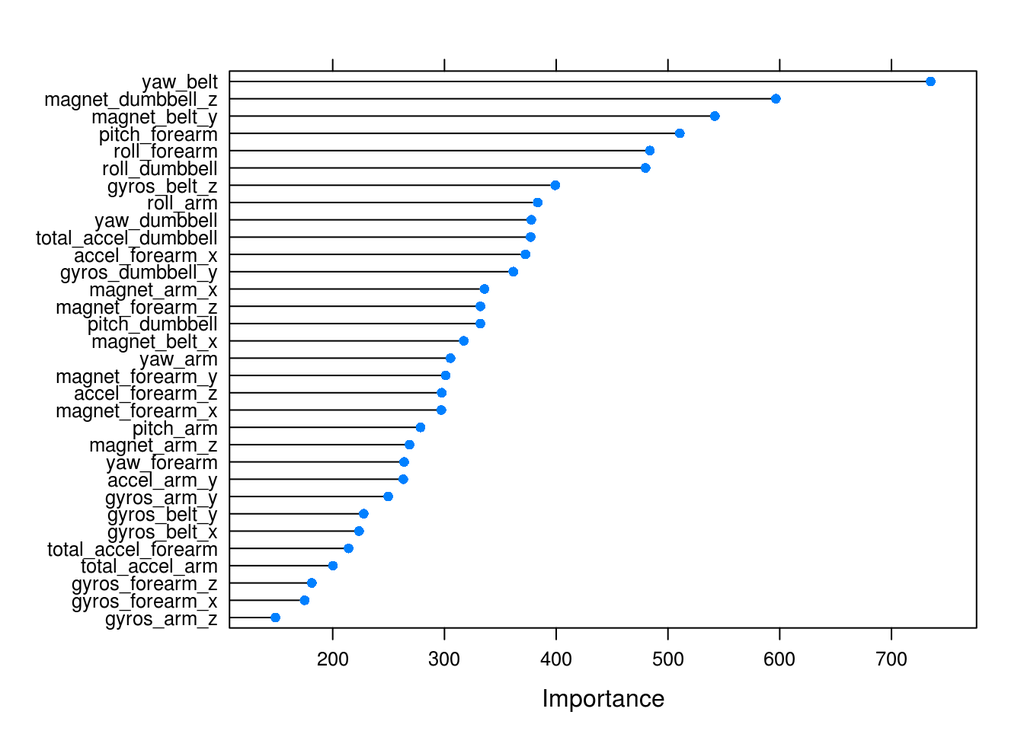

```r
importance <- varImp(modelRF, scale = FALSE)
plot(importance, top = 32)
```

Top 6 features look relatively more important than the rest, probably could have created model with less features.

# predict on testing data

Let’s use our model to predict

```r
testing <- read.csv("pml-testing.csv", header = TRUE, na.strings=na_strings)

testPred <- predict(modelRF, testing)
testPred
```

```
##  [1] B A B A A E D B A A B C B A E E A B B B
## Levels: A B C D E
```